# Data Science With an Eye Towards Sustainability Activity A9: Exploratory Data Analysis

# 1 Exploratory Data Analysis

Activity prompt: What are the first steps to take when you start a project or get ahold of a new data set?

Additional reading:

- Grolemund and Wickham’s [Exploratory Data Analysis](https://r4ds.had.co.nz/exploratory-data-analysis.html)
- [Exploratory Data Analysis Checklist](https://bookdown.org/rdpeng/exdata/exploratory-data-analysis-checklist.html), by Roger Peng

In a real data science project, you will typically have a question or idea brought to you: How are people interacting with the new version of my software? How is weather in Alaska changing in the last decade? What type of people are most likely to enroll in Obamacare?

You will sometimes be given a dataset when asked one of these questions, or more often, a general description of the data you *could* get if you talked to the right people or interacted with the right software systems.

We view the process similarly:

1. **Understand** the basic data that is available to you.
2. **Visualize and describe** the variables that seem most interesting or relevant.
3. **Formulate** a research question.
4. **Analyze** the data related to the research question, starting from simple analyses to more complex ones.
5. **Interpret** your findings, **refine** your research question, and return to step 4.

## 1.1 Understand the Basic Data

Start by understanding the data that is available to you. If you have a codebook, you have struck gold! If not (the more common case), you’ll need to do some detective work that often involves talking to people. At this stage, ask yourself:

- Where does my data come from? How was it collected?[^1]
- Is there a codebook? If not, how can I learn about it?
- Are there people I can reach out to who have experience with this data?

Next, you need to load the data and clean it. Once the data is loaded, ask yourself about each table:

- What is an observation?
- How many observations are there?
- What is the meaning of each variable?
- What is the type of each variable (date, location, string, factor, number, boolean, etc.)?

Some great methods to start with are the functions

- `glimpse()` to learn about the numbers of variables and observations as well as the classes of variables
- `head()` to view the top of the data table (can specify the number of rows with `n=` )
- `tail()` to view the bottom of the data table

Here is an example with the [Kaggle World Sustainability Dataset](https://www.kaggle.com/datasets/truecue/worldsustainabilitydataset):

```r
world_sust<-read_csv("http://faculty.olin.edu/dshuman/DS/WorldSustainabilityDataset.csv")%>%
    janitor::clean_names()
```

The data dictionary is [here](https://www.kaggle.com/datasets/truecue/worldsustainabilitydataset?select=Data+Dictionary.xlsx).

```r
world_sust_15<-world_sust%>%
  filter(year==2015)%>%
  rename(population=population_total_sp_pop_totl,
         region_un=world_regions_un_sdg_definition,
         rural_pop=rural_population_percent_of_total_population_sp_rur_totl_zs,
         life_expectancy=life_expectancy_at_birth_total_years_sp_dyn_le00_in,
         internet=individuals_using_the_internet_percent_of_population_it_net_user_zs,
         elec_access=access_to_electricity_percent_of_population_eg_elc_accs_zs,
         gdp_per_capita=gdp_per_capita_current_us_ny_gdp_pcap_cd,
         compulsory_ed_years=compulsory_education_duration_years_se_com_durs,
         primary_enroll=school_enrollment_primary_percent_gross_se_prm_enrr,
         secondary_enroll=school_enrollment_secondary_percent_gross_se_sec_enrr,
         unemployment_male=unemployment_rate_male_percent_sl_tlf_uem_8_5_2,
         unemployment_women=unemployment_rate_women_percent_sl_tlf_uem_8_5_2,
         drinking_water_perc=proportion_of_population_using_basic_drinking_water_services_percent_sp_acs_bsrvh2o_1_4_1,
         below_poverty_line=proportion_of_population_below_international_poverty_line_percent_si_pov_day1_1_1_1,
         undernourishment=prevalence_of_undernourishment_percent_sn_itk_defc_2_1_1)%>%
  select(country_name,population,region_un,rural_pop,life_expectancy,internet,elec_access,gdp_per_capita,compulsory_ed_years,primary_enroll,secondary_enroll,unemployment_male,unemployment_women,drinking_water_perc,below_poverty_line,undernourishment)
```

```r
glimpse(world_sust_15)
```

```
## Rows: 173
## Columns: 16
## $ country_name        <chr> "Aruba", "Angola", "Albania", "United Arab Emirate…
## $ population          <dbl> 104339, 27884380, 2880703, 9262896, 43131966, 2925…
## $ region_un           <chr> "Latin America and Caribbean", "Sub-Saharan Africa…
## $ rural_pop           <dbl> 56.892, 36.554, 42.566, 14.326, 8.497, 36.915, 75.…
## $ life_expectancy     <dbl> 75.72500, 59.39800, 78.02500, 77.28500, 76.06800, …
## $ internet            <dbl> 88.66123, 29.00000, 56.90000, 90.50000, 68.04306, …
## $ elec_access         <dbl> 100.00000, 42.00000, 99.98000, 100.00000, 99.81168…
## $ gdp_per_capita      <dbl> 28396.9084, 4166.9798, 3952.8012, 38663.4005, 1378…
## $ compulsory_ed_years <dbl> 13, 6, 9, 6, 14, 12, 11, 10, 10, 10, NA, 12, 6, 10…
## $ primary_enroll      <dbl> NA, 113.47796, 105.54298, 111.54276, 111.30341, 95…
## $ secondary_enroll    <dbl> NA, NA, 97.38848, NA, 106.94647, 86.00589, 108.230…
## $ unemployment_male   <dbl> NA, NA, 17.3, NA, NA, 17.4, NA, 6.0, 6.1, 4.1, NA,…
## $ unemployment_women  <dbl> NA, NA, 17.1, NA, NA, 19.2, NA, 6.1, 5.3, 5.9, NA,…
## $ drinking_water_perc <dbl> NA, NA, 93, NA, NA, 100, NA, 100, 100, 92, NA, 100…
## $ below_poverty_line  <dbl> NA, NA, 1.1, NA, NA, 1.3, NA, NA, 0.7, NA, NA, 0.1…
## $ undernourishment    <dbl> NA, 14.5, 4.7, 2.7, NA, 2.8, NA, NA, NA, NA, NA, N…
```

```r
head(world_sust_15)
```

```
## # A tibble: 6 × 16
##   country_name         population region_un   rural_pop life_expectancy internet
##   <chr>                     <dbl> <chr>           <dbl>           <dbl>    <dbl>
## 1 Aruba                    104339 Latin Amer…     56.9             75.7     88.7
## 2 Angola                 27884380 Sub-Sahara…     36.6             59.4     29
## 3 Albania                 2880703 Europe and…     42.6             78.0     56.9
## 4 United Arab Emirates    9262896 Northern A…     14.3             77.3     90.5
## 5 Argentina              43131966 Latin Amer…      8.50            76.1     68.0
## 6 Armenia                 2925559 Northern A…     36.9             74.5     59.1
## # ℹ 10 more variables: elec_access <dbl>, gdp_per_capita <dbl>,
## #   compulsory_ed_years <dbl>, primary_enroll <dbl>, secondary_enroll <dbl>,
## #   unemployment_male <dbl>, unemployment_women <dbl>,
## #   drinking_water_perc <dbl>, below_poverty_line <dbl>, undernourishment <dbl>
```

```r
tail(world_sust_15)
```

```
## # A tibble: 6 × 16
##   country_name  population region_un          rural_pop life_expectancy internet
##   <chr>              <dbl> <chr>                  <dbl>           <dbl>    <dbl>
## 1 Venezuela, RB   30081827 Latin America and…      11.8            72.6     NA
## 2 Vietnam         92677082 Eastern and South…      66.2            75.1     45
## 3 Vanuatu           271128 Oceania                 75.0            69.9     22.4
## 4 South Africa    55386369 Sub-Saharan Africa      35.2            62.6     51.9
## 5 Zambia          15879370 Sub-Saharan Africa      58.1            61.7     NA
## 6 Zimbabwe        13814642 Sub-Saharan Africa      67.6            59.5     22.7
## # ℹ 10 more variables: elec_access <dbl>, gdp_per_capita <dbl>,
## #   compulsory_ed_years <dbl>, primary_enroll <dbl>, secondary_enroll <dbl>,
## #   unemployment_male <dbl>, unemployment_women <dbl>,
## #   drinking_water_perc <dbl>, below_poverty_line <dbl>, undernourishment <dbl>
```

Finally, ask yourself about the relationships between tables:

- What variables link the tables (i.e., which variables can you use in `join` commands)?

## 1.2 Visualize and Describe the Data

Once you have the data loaded and cleaned, it is usually helpful to do some univariate visualization; e.g., plotting histograms, densities, and box plots of different variables. You might ask questions such as:

- What do you see that is interesting?
- Which values are most common or unusual (outliers)?
- Is there a lot of missing data?
- What type of variation occurs within the individual variables?
- What might be causing the interesting findings?
- How could you figure out whether your ideas are correct?

Once you have done some univariate visualization, you might examine the **covariation** between different variables. One convenient way to do this is with a `pairs` plot.

Here are three different versions of such plots. The main point of these plots is not necessarily to draw any conclusions, but to help generate more specific research questions and hypotheses.

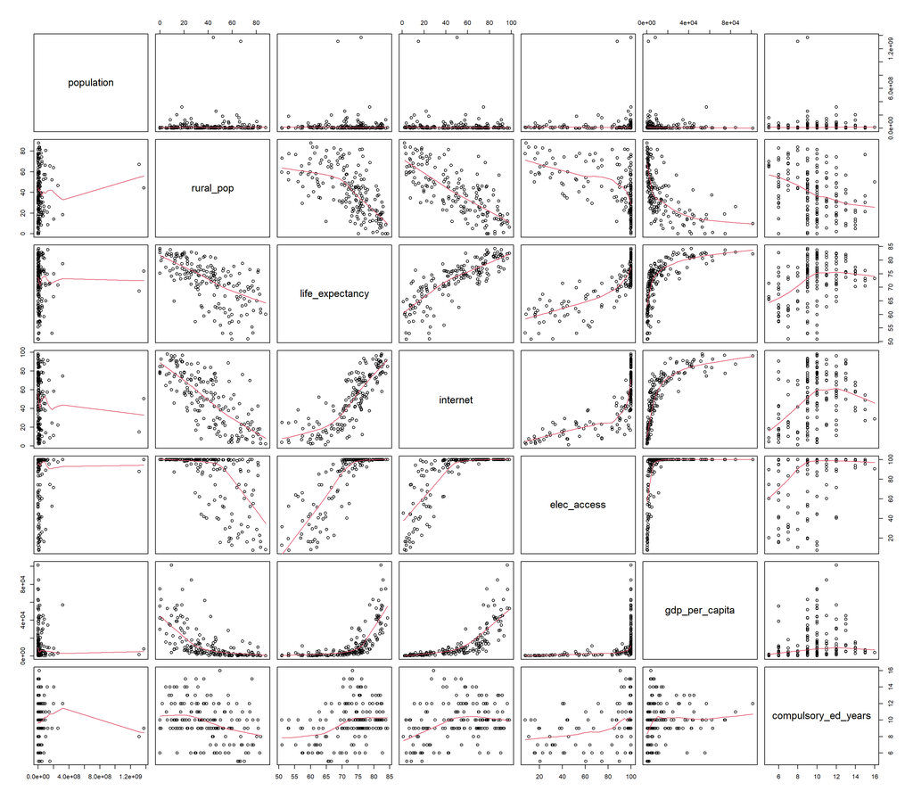

```r
pairs(world_sust_15[,c(2,4:9)], bg="lightblue",panel=panel.smooth)
```

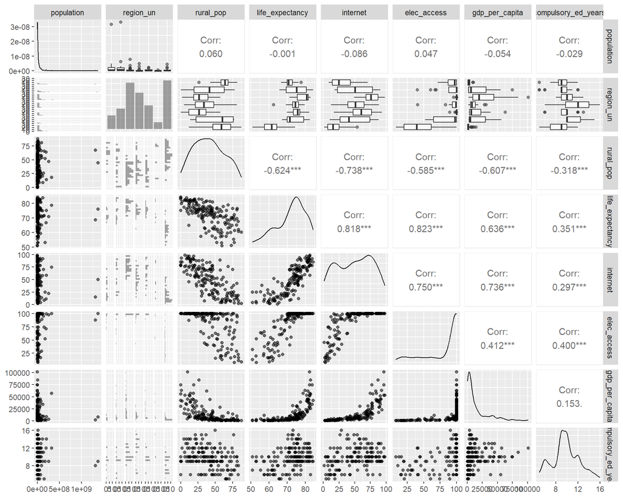

```r
ggpairs(world_sust_15[,2:9], aes(alpha = 0.4))
```

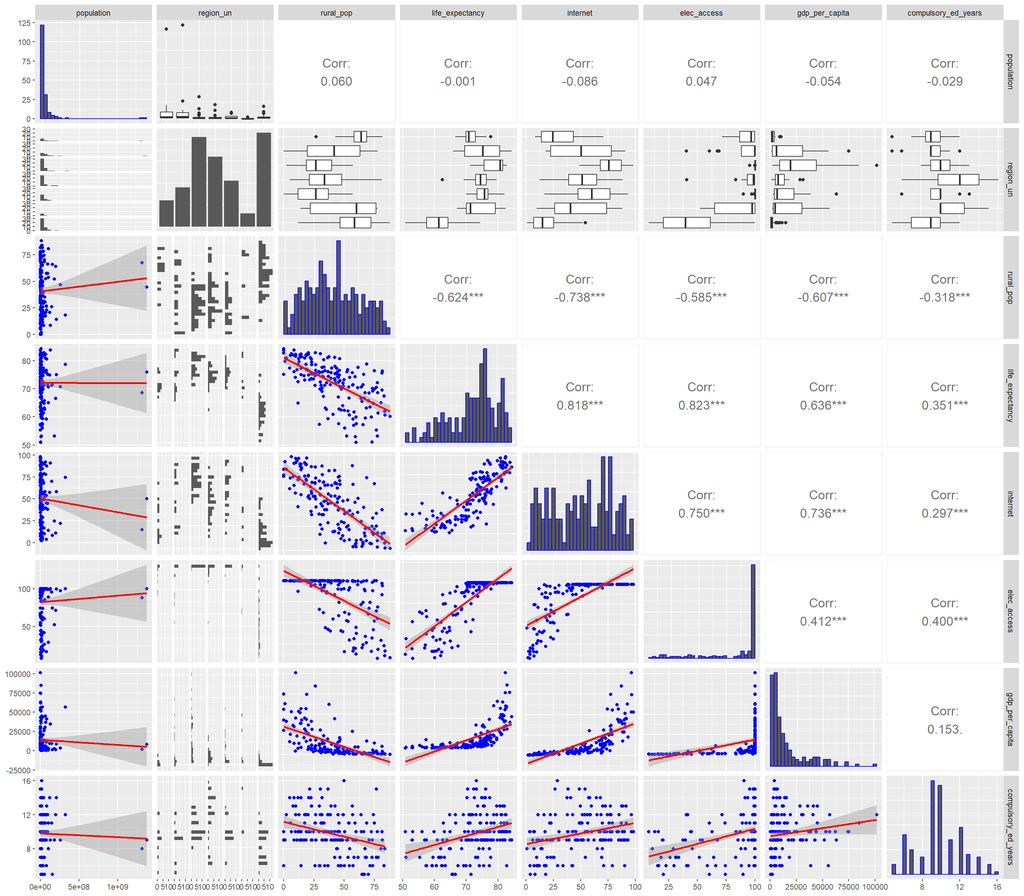

```r
lowerFn <- function(data, mapping, method = "lm", ...) {
  p <- ggplot(data = data, mapping = mapping) +
    geom_point(colour = "blue") +
    geom_smooth(method = method, color = "red", ...)
  p
}

ggpairs(
  world_sust_15[,2:9], lower = list(continuous = wrap(lowerFn, method = "lm")),
  diag = list(continuous = wrap("barDiag", colour = "blue")),
  upper = list(continuous = wrap("cor", size = 5))
)
```

## 1.3 Formulate a Research Question

You will often end up with a ton of data, and it can be easy to be overwhelmed. How should you get started? One easy idea is to brainstorm ideas for research questions, and pick one that seems promising. This process is much easier with more than one brain! You will often be working off of a broad question posed by your business, organization, or supervisor, and be thinking about how to narrow it down. To do so, you can again revisit questions like “What patterns do you see?” or “Why might they be occurring?”

## 1.4 Examples

Here are some exploratory data analysis examples I like:

- [Crime mapping](https://www.kaggle.com/mircat/violent-crime-mapping)
- [Changes in fine particle air pollution in the US](https://bookdown.org/rdpeng/exdata/data-analysis-case-study-changes-in-fine-particle-air-pollution-in-the-u-s-.html)
- [Married people have more sex](http://flowingdata.com/2017/07/03/married-people-sex/)[^2]
- [Tropical storm analysis](https://www.r-bloggers.com/2017/09/exploratory-data-analysis-of-tropical-storms-in-r/)

# 2 Practice: Wastewater Treatement Plants

Wastewater treatment plants remove contaminents (pathogens, nutrients, organics, and other pollutants) from wastewater, and then typically return the treated water (an *effluent*) into surface waters such as streams, rivers, and wetlands. Here is an overview of [how the Massachusetts sewer system works](https://www.mwra.com/03sewer/html/sewhow.htm) and more details on the [major components of the Deer Island Wastewater Treamtement Plant](https://www.mwra.com/03sewer/html/sewditp.htm). Here is a [wastewater treatment overview video](https://www.youtube.com/watch?v=FvPakzqM3h8) and its [condensed version](https://www.youtube.com/watch?v=cUFKay8VPqo).

The [HydroSHEDS project](https://www.hydrosheds.org/about) recently compiled data on 58,502 wastewater treatment plants into the [HydroWASTE](https://www.hydrosheds.org/products/hydrowaste) database. The authors published a [2022 article in Earth System Science Data](https://essd.copernicus.org/articles/14/559/2022/essd-14-559-2022.pdf) describing the database. This data set was [featured](https://github.com/rfordatascience/tidytuesday/tree/master/data/2022/2022-09-20) on [TidyTuesday](https://github.com/rfordatascience/tidytuesday/tree/master), a weekly data project where people from the `R` for Data Science (R4DS) online learning community each make a visualization from the same dataset and post them online. You should try to do TidyTuesday sometime.

Here are ten different tables for you to use for this activity:

```r
ww_plants<-read_csv("http://faculty.olin.edu/dshuman/DS/hydrowaste/HydroWASTE_v10.csv")%>%
  janitor::clean_names()
north_america_river_atlas<-read_csv("http://faculty.olin.edu/dshuman/DS/hydrowaste/north_america_river_atlas.csv")
biome_codebook<-read_csv("http://faculty.olin.edu/dshuman/DS/hydrowaste/biome_codebook.csv")
climate_zone_codebook<-read_csv("http://faculty.olin.edu/dshuman/DS/hydrowaste/climate_zone_codebook.csv")
country_abbreviation_codebook<-read_csv("http://faculty.olin.edu/dshuman/DS/hydrowaste/country_abbreviation_codebook.csv")
freshwater_ecoregion_codebook<-read_csv("http://faculty.olin.edu/dshuman/DS/hydrowaste/freshwater_ecoregion_codebook.csv")
major_habitat_type_codebook<-read_csv("http://faculty.olin.edu/dshuman/DS/hydrowaste/major_habitat_type_codebook.csv")
potential_natural_veg_class_codebook<-read_csv("http://faculty.olin.edu/dshuman/DS/hydrowaste/potential_natural_veg_class_codebook.csv")
terrestrial_ecoregion_codebook<-read_csv("http://faculty.olin.edu/dshuman/DS/hydrowaste/terrestrial_ecoregion_codebook.csv")
wetland_class_codebook<-read_csv("http://faculty.olin.edu/dshuman/DS/hydrowaste/wetland_class_codebook.csv")
```

**Exercise 2.1 (Explore the wastewater plant data)** Here is the [data dictionary](http://faculty.olin.edu/dshuman/DS/hydrowaste/hydrowaste_README.txt) for the HydroWASTE data in `ww_plants`. What does each row correspond to? Make sure to understand the different variables. Where in the world are the wastewater plants in the database? Which plants have effluents that flow into oceans or large lakes? How many of those are there? What is `df`? How is calculuated? What `df` levels are commonly considered as cause for environmental concern? All of these questions can be answered by skimming the [journal article](https://essd.copernicus.org/articles/14/559/2022/essd-14-559-2022.pdf).

*Solution*.

- Each row is one wastewater treatment plant
- Data for plants over the world
- Plants that have `df = na` have effluents that flow into oceans or large lakes
- There are 11200 such plants, out of 58502
- `df` is estimated dilution factor, which is calculated as “the ratio of the natural discharge of the receiving waterbody to the WWTP effluent discharge”
- if `df` is less than 10, then it is cause for environmental concern

```r
ww_plants %>%
  filter(is.na(df)) %>%
  count()
```

```
## # A tibble: 1 × 1
##       n
##   <int>
## 1 11200
```

**Exercise 2.2 (Explore the North America river atlas)** The `north_america_river_atlas` table is extracted from the [HydroRIVERS database](https://www.hydrosheds.org/products/hydrorivers).

- The variable `hyriv_id` is a unique identifier for each river reach. The code consists of 8 digits, where the first digit represents the region: 1 = Africa; 2 = Europe; 3 = Siberia; 4 = Asia; 5 = Australia; 6 = South America; 7 = North America; 8 = Arctic; 9 = Greenland; and the other seven digits represent a unique identifier within the river network.
- The variable `main_riv` is the `hyriv_id` of the most downstream reach of the connected river basin. It can be used to identify the entire river network that the river reach belongs to.
- To reduce download size, we’ve only given you the river reaches in North America (and a subset of the variables). If you want to use the rest, you can find them in the shapefiles [here](https://www.hydrosheds.org/products/hydrorivers).

**Exercise 2.3 (Possible joins)**

*Solution*.

1. `hyriv_id`
2. refer to codebooks

```r
north_america_river_atlas_expanded <- north_america_river_atlas %>%
  left_join(wetland_class_codebook, by="wetland_class_id") %>%
  left_join(freshwater_ecoregion_codebook, by="freshwater_ecoregion_id") %>%
  left_join(major_habitat_type_codebook, by="major_habitat_type_id") %>%
  left_join(climate_zone_codebook, by="climate_zone_id") %>%
  left_join(terrestrial_ecoregion_codebook, by="terrestrial_ecoregion_id") %>%
  left_join(biome_codebook, by="biome_id") %>%
  left_join(potential_natural_veg_class_codebook, by="potential_natural_veg_class_code")

north_america_river_atlas_expanded
```

```
## # A tibble: 986,463 × 17
##    hyriv_id main_riv wetland_class_id freshwater_ecoregion_id climate_zone_id
##       <dbl>    <dbl>            <dbl>                   <dbl>           <dbl>
##  1 70000001 70000001             -999                     112               6
##  2 70000002 70000002             -999                     112               6
##  3 70000003 70000003             -999                     113               4
##  4 70000004 70000004             -999                     113               4
##  5 70000005 70000005             -999                     113               4
##  6 70000006 70000006             -999                     113               4
##  7 70000007 70000007             -999                     113               4
##  8 70000008 70000007             -999                     113               4
##  9 70000009 70000007             -999                     113               4
## 10 70000010 70000010             -999                     113               4
## # ℹ 986,453 more rows
## # ℹ 12 more variables: terrestrial_ecoregion_id <dbl>,
## #   potential_natural_veg_class_code <dbl>, wetland_class_name <chr>,
## #   freshwater_ecoregion_name <chr>, major_habitat_type_id <dbl>,
## #   major_habitat_type_name <chr>, climate_zone_name <chr>,
## #   climate_zone_code <chr>, terrestrial_ecoregion_name <chr>, biome_id <dbl>,
## #   biome_name <chr>, potential_natural_veg_class_name <chr>
```

**Exercise 2.4 (Broad research question(s))** There is a ton of data here, and it can be easy to be overwhelmed. Try to focus your exploration a bit by identifying one or two broad research avenues. Here are some examples, some of which are taken from the [article on HydroWASTE](https://essd.copernicus.org/articles/14/559/2022/essd-14-559-2022.pdf) (feel free to use these or come up with your own):

- Better understand the wastewater plants that have dilution factors under 10: Where are they? What level facilities do they tend to be? To which river networks do their outfall locations lead?
- Are there large geographic areas (by population or land area) whose wastewater is not being effectively treated by plants in the database?
- For which wastewater plants might an upgrade in technology deliver the biggest improvement of downstream water quality?
- Policy analysis: Where should local regulations be established to limit the release of pollutants? How are past policy decisions evident in the data?
- Where does most treated water go? To rivers? To oceans or large lakes? Back into a water treatment plant for drinkable water (full cycle reuse)?

All of these topics are closely related the United Nations’ Sustainable Development Goal 6: “Ensure availability and sustainable management of water and sanitation for all.”

**Exercise 2.5 (Visualize and describe the data)** Use some univariate and bivariate visualizations to start to explore the questions you identified:

- What do you see that is interesting?
- Which values are most common or unusual (outliers)?
- Is there a lot of missing data?
- What type of variation occurs within the individual variables?
- What might be causing the interesting findings?
- How could you figure out whether your ideas are correct?

```r
ww_plants_expanded <- ww_plants %>%
  inner_join(north_america_river_atlas_expanded, by="hyriv_id")
```

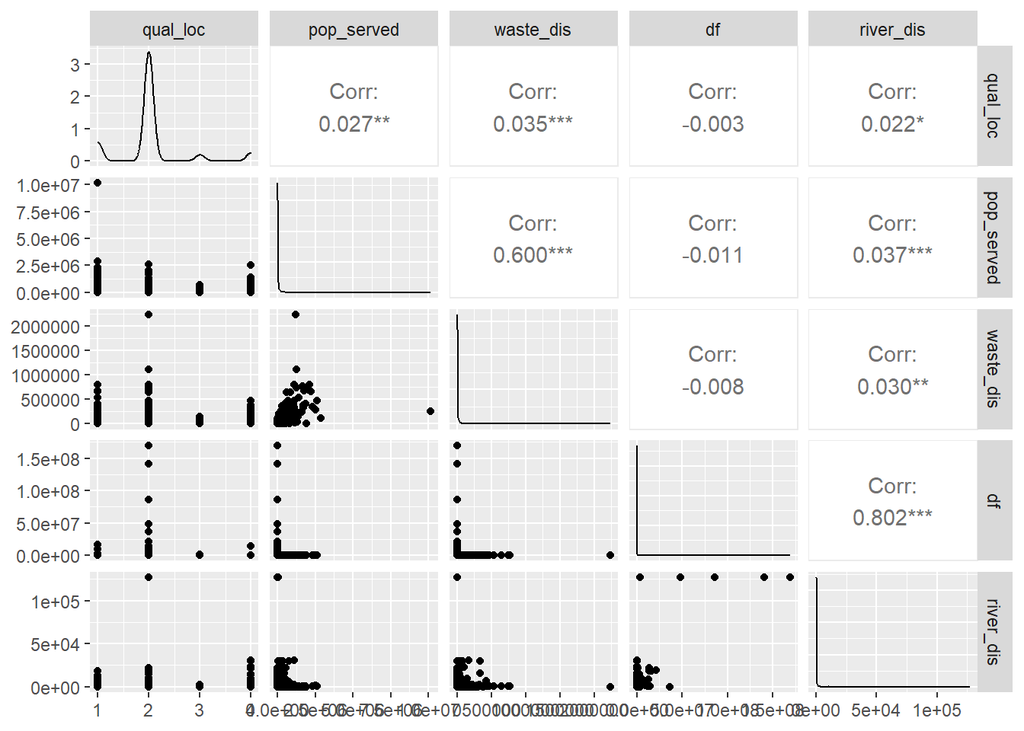

```r
# ggpairs(
#   sample_n(ww_plants[,c(9, 12:25)], 1000)
# )
ggpairs(
  sample_n(ww_plants[,c(9, 13, 15, 19, 21)], 10000)
)
```

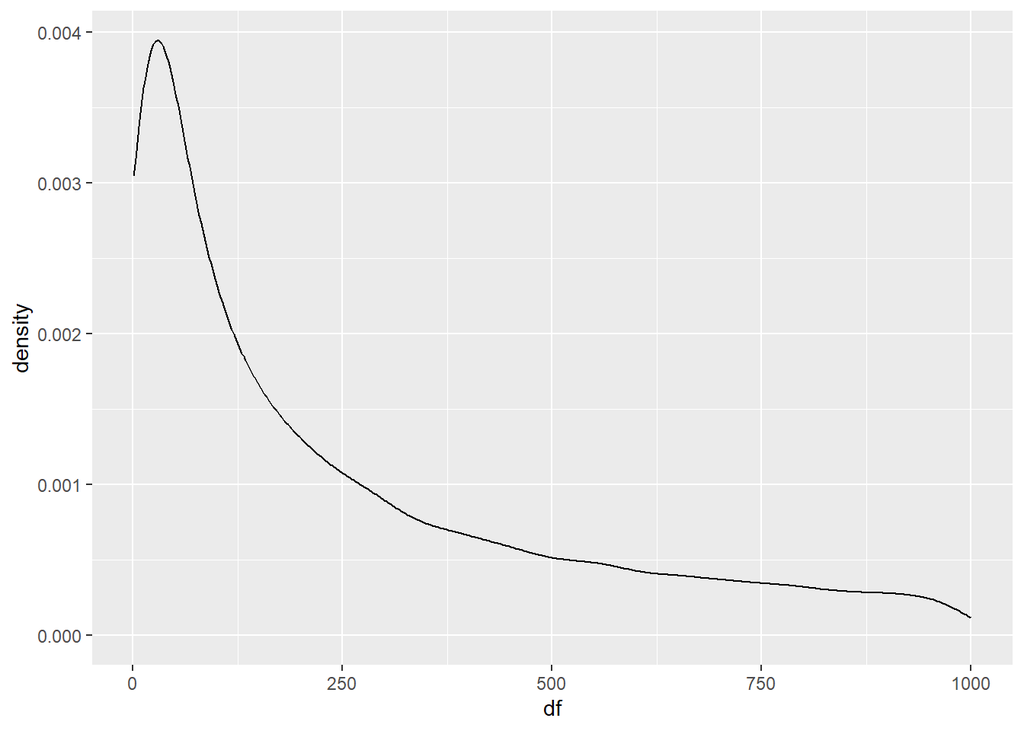

```r
ggplot(ww_plants %>%filter(df < 1000))+
  geom_density(aes(x=df))
```

```r
filter(ww_plants, df < 1000)
```

```
## # A tibble: 27,584 × 25
##    waste_id source org_id wwtp_name country cntry_iso lat_wwtp lon_wwtp qual_loc
##       <dbl>  <dbl>  <dbl> <chr>     <chr>   <chr>        <dbl>    <dbl>    <dbl>
##  1        5      1 1.14e6 Baisogal… Lithua… LTU           55.6     23.7        2
##  2        7      1 1.14e6 Birzu ag… Lithua… LTU           56.2     24.7        2
##  3        9      1 1.14e6 Eisiskiu… Lithua… LTU           54.2     25.0        2
##  4       10      1 1.14e6 Elektren… Lithua… LTU           54.8     24.6        2
##  5       12      1 1.14e6 Ignalino… Lithua… LTU           55.3     26.2        2
##  6       14      1 1.14e6 Joniskio… Lithua… LTU           56.3     23.6        2
##  7       17      1 1.14e6 Kaisiado… Lithua… LTU           54.9     24.4        2
##  8       18      1 1.14e6 Kalvarij… Lithua… LTU           54.4     23.2        2
##  9       19      1 1.14e6 Kauno m … Lithua… LTU           54.9     23.9        2
## 10       20      1 1.14e6 Kazlu Ru… Lithua… LTU           54.8     23.5        2
## # ℹ 27,574 more rows
## # ℹ 16 more variables: lat_out <dbl>, lon_out <dbl>, status <chr>,
## #   pop_served <dbl>, qual_pop <dbl>, waste_dis <dbl>, qual_waste <dbl>,
## #   level <chr>, qual_level <dbl>, df <dbl>, hyriv_id <dbl>, river_dis <dbl>,
## #   coast_10km <dbl>, coast_50km <dbl>, design_cap <dbl>, qual_cap <dbl>
```

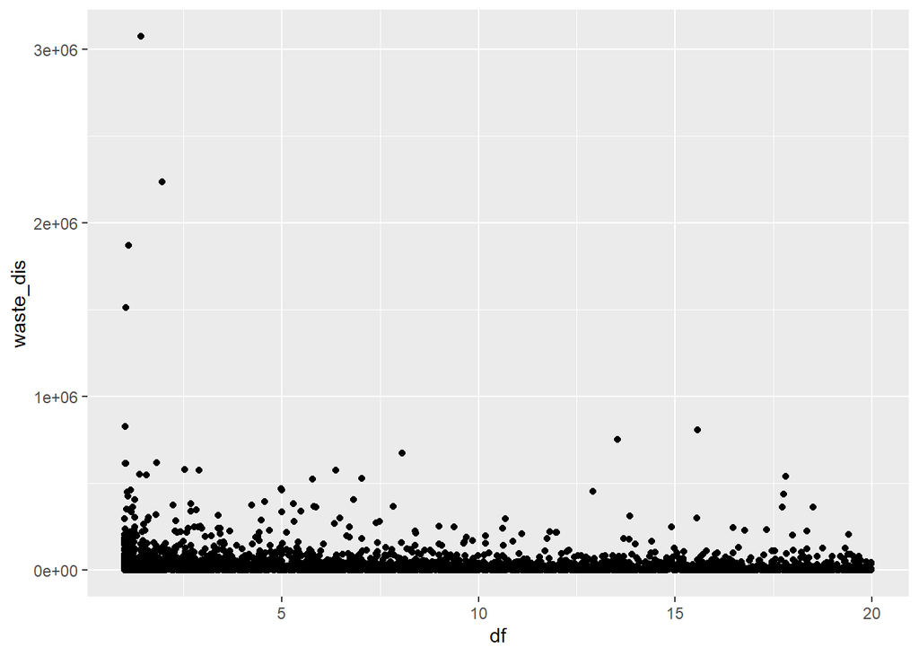

```r
ggplot(ww_plants %>%filter(df < 20))+
  geom_point(aes(x=df, y=waste_dis))
```

```r
bigfour <- ww_plants_expanded %>%
  filter(df < 10, waste_dis > 1*10^6)
```

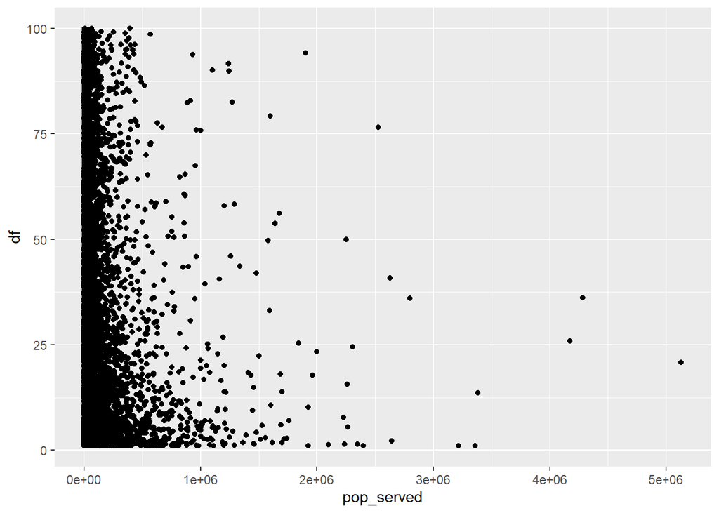

```r
ggplot(ww_plants %>% filter(df < 100))+
  geom_point(aes(y=df, x=pop_served))
```

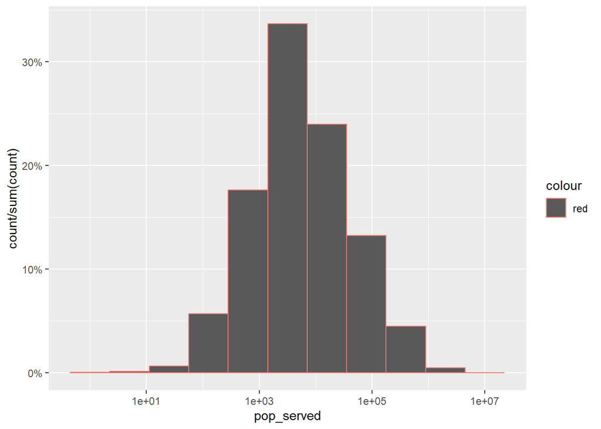

```r
ggplot(ww_plants %>% filter(pop_served != -1))+
  geom_histogram(aes(
    x=pop_served,
    after_stat(count / sum(count)),
    color="red"
    ),
    binwidth = 0.7)+
  scale_x_log10()+
  scale_y_continuous(labels = scales::percent)
```

```r
ww_plants %>% filter(pop_served > 300000) %>% count / ww_plants %>% count
```

```
##            n
## 1 0.02697344
```

[figure not shown]

```r
ggplot(ww_plants %>%  filter(is.na(df)))+
  geom_point(aes(y=df, x=pop_served))
```

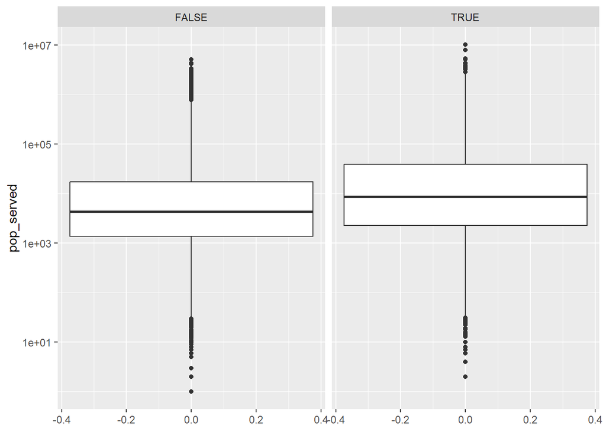

```r
ggplot(ww_plants)+
  geom_boxplot(aes(y=pop_served))+
  facet_wrap(~is.na(df))+
  scale_y_log10()
```

```r
library(ggmap)
register_stadiamaps("5081c024-5bc9-46e4-b756-897ac8e430cd", write = TRUE)
```

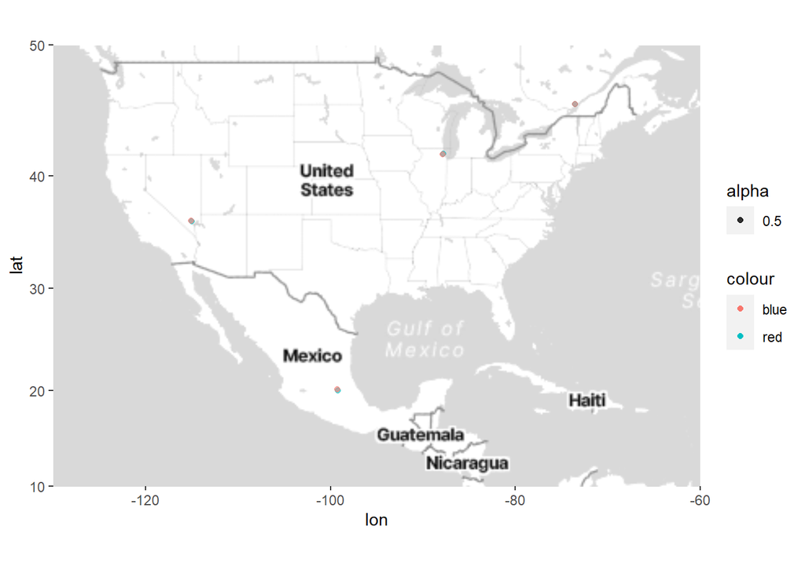

```r
bbox<-c(-130,10,-60,50)
ggmap(get_stadiamap(bbox = bbox, maptype = "stamen_toner_lite", zoom = 3)) +
  geom_point(data=bigfour, aes(x=lon_wwtp, y=lat_wwtp, alpha=0.5, color="red")) +
  geom_point(data=bigfour, aes(x=lon_out, y=lat_out, alpha=0.5, color="blue"))
```

**Exercise 2.6 (Formulate a specific research question)** Based on your preliminary visualizations and exploration of the date, formulate a more specific research question/hypothesis within your broad research question. The more you can iteratively narrow this question, the more interesting insights you might find. For example, you may want to hone in on a specific geographical region or wastewater plants with specific properties.

**Exercise 2.7 (Use visualizations to tell a story)** Iteratively develop one to three visualizations that tell a story about your more specific research question/hypothesis. Note: the story may very well be something along the lines of “we thought variable X might be associated with pattern Y, but the evidence does not support that.”

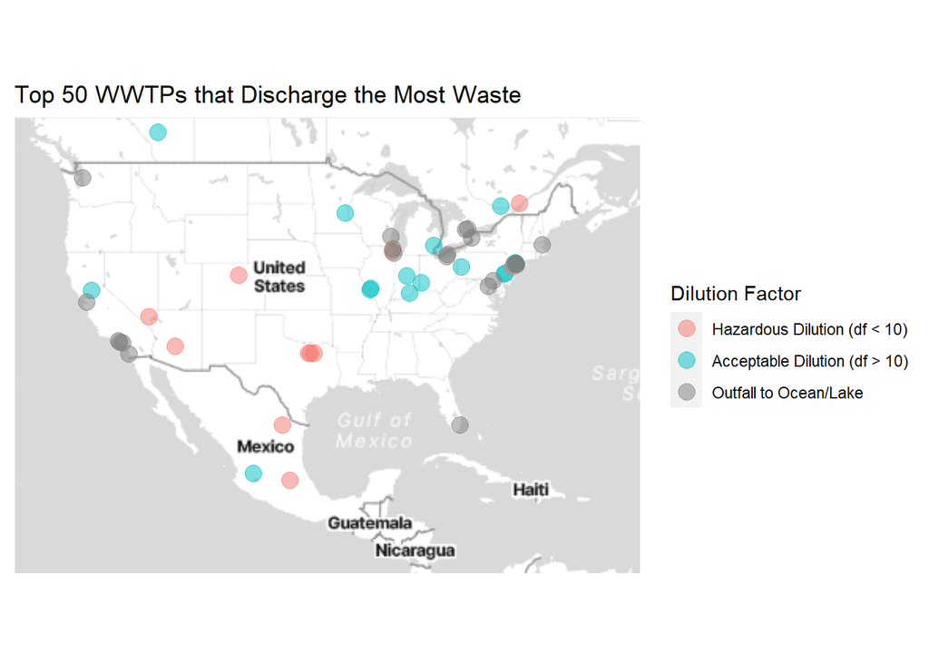

```r
bbox<-c(-130,10,-60,52)
ggmap(get_stadiamap(bbox = bbox, maptype = "stamen_toner_lite", zoom = 3)) +
  geom_point(data=ww_plants_expanded %>%
                    arrange(desc(waste_dis)) %>%
                    head(n=50)
             , aes(x=lon_wwtp, y=lat_wwtp, color=df>10), alpha=0.5, size=4)+
  scale_color_discrete(name = "Dilution Factor",
                       labels = c("Hazardous Dilution (df < 10)", "Acceptable Dilution (df > 10)", "Outfall to Ocean/Lake "))+
  labs(
    title="Top 50 WWTPs that Discharge the Most Waste",

  )+
  theme(
    axis.title.x=element_blank(),
    axis.text.x=element_blank(),
    axis.ticks.x=element_blank(),
    axis.title.y=element_blank(),
    axis.text.y=element_blank(),
    axis.ticks.y=element_blank(),

  )
```

[figure not shown]

```r
bbox<-c(-87.9322,41.7488,-87.5250,41.9145)
ggmap(get_stadiamap(bbox = bbox, maptype = "stamen_terrain", zoom = 11))+
  geom_point(data=bigfour[1,], aes(x=lon_wwtp, y=lat_wwtp), color="red", size=8, shape=18)+
  theme(
    axis.title.x=element_blank(),
    axis.title.y=element_blank(),

  )
```

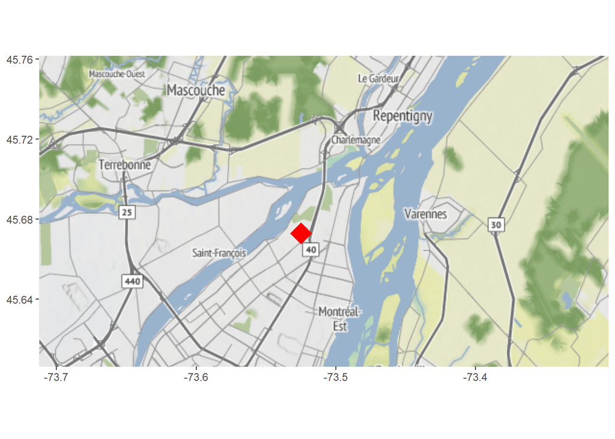

```r
bbox<-c(-73.7124,45.6063,-73.3052,45.7618)
ggmap(get_stadiamap(bbox = bbox, maptype = "stamen_terrain", zoom = 11))+
  geom_point(data=bigfour[4,], aes(x=lon_wwtp, y=lat_wwtp), color="red", size=8, shape=18)+
  theme(
    axis.title.x=element_blank(),
    axis.title.y=element_blank(),

  )
```

[^1]: Particularly important questions about how it was collected include whether it is a sample of a larger data set, and, if so, how the sampling was done? Randomly? All cases during a specific time frame? All data for a selected set of users? Answers to such questions strongly impact the conclusions you will be able to draw from the data.
[^2]: The graphics in this one are a bit more developed than you would really see in an exploratory analysis, but I think the progression of visualizations is interesting and follows an exploratory story.